# Lab 1

Evan O’Toole

January, 24th, 2025

# Likelihood methods for the Binomial distribution

- Put your name in the author section.
- Execute each chunk of code to ensure that your code works properly. The TA will review the code with you.
- Sometimes one of your chucks of code will not compile properly, but you must hand your document in. In that case, ‘Comment’ out the R code that is not working properly using #. Do that now. For the chuck of code in Section number 4, below, put # at the start of each line of R code.
- Compute question 6 below. Execute the question 6 code to ensure that it works properly. If you cannot compile it without errors before the end of the class, comment out the chunk.
- Then HTML knit the entire document.
- Open the HTML document in a browser.
- Save the HTML file as a pdf file and upload it to the Practice Lab Assignment Activity in the Lab section of CourseSpaces.

## 1. First we generate 1 observation from the Binomial(100, theta=.07) distribution

```r
#This is a comment inside of a chunk of R code.

set.seed(54321)   #setting the random number generator seed SHOULD always be done before simulating
# Ask your Lab instructor to explain set.seed()
bdat <- rbinom(1, size=100, prob=.07 )   # see ?rbinom for information
bdat
```

```
## [1] 6
```

## 2. We know that the MLE for the probability of success, theta, is the sample proportion.

```r
thetahat <- bdat/100
thetahat
```

```
## [1] 0.06
```

The MLE of theta is 0.06.

## 3. Compute the vector of Log-Likelihoods for a sequence of values for theta given the one data point bdat.

```r
theta <- seq(0.02, 0.14, by=.005)   #creates a vector of values from .02 to .14 in steps of .005
bloglike <- dbinom(bdat, size=100, prob=theta, log=TRUE)  #computes log of binomial probabilities
cbind(theta, bloglike)
```

```
##       theta  bloglike
##  [1,] 0.020 -4.472250
##  [2,] 0.025 -3.614208
##  [3,] 0.030 -3.003571
##  [4,] 0.035 -2.564456
##  [5,] 0.040 -2.251580
##  [6,] 0.045 -2.035745
##  [7,] 0.050 -1.897021
##  [8,] 0.055 -1.821203
##  [9,] 0.060 -1.797810
## [10,] 0.065 -1.818888
## [11,] 0.070 -1.878263
## [12,] 0.075 -1.971046
## [13,] 0.080 -2.093301
## [14,] 0.085 -2.241816
## [15,] 0.090 -2.413935
## [16,] 0.095 -2.607439
## [17,] 0.100 -2.820457
## [18,] 0.105 -3.051394
## [19,] 0.110 -3.298886
## [20,] 0.115 -3.561754
## [21,] 0.120 -3.838976
## [22,] 0.125 -4.129658
## [23,] 0.130 -4.433017
## [24,] 0.135 -4.748363
## [25,] 0.140 -5.075086
```

## 4. Plot the Log-Likelihood function versus theta.

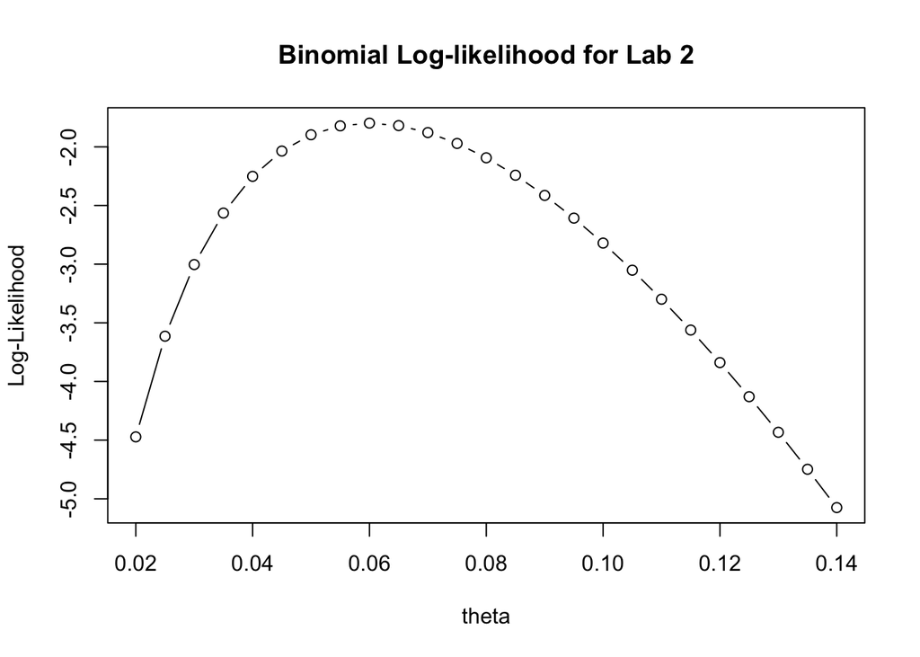

```r
plot(bloglike~theta, ylab='Log-Likelihood', xlab='theta', type='b')
title('Binomial Log-likelihood for Lab 2')
```

## 5. Generate n=10 observations from the same distribution and plot the log-likelihood function given the n observations.

```r
set.seed(54321)
n <- 10
bdat2 <- rbinom(n, size=100, prob=.07 )   # this generates n binomial observations
bdat2
```

```
##  [1]  6  7  5  5  5 10  3  5  6  6
```

```r
theta <- seq(0.02, 0.14, by=.005)

bloglike2 <- 0
for (i in 1:n){
bloglike2 <- bloglike2 + dbinom(bdat2[i], size=100, prob=theta, log=TRUE)
      #computes the sum of the log of binomial probabilities over the observations
}

cbind(theta, bloglike2)
```

```
##       theta bloglike2
##  [1,] 0.020 -44.71201
##  [2,] 0.025 -36.58811
##  [3,] 0.030 -30.85666
##  [4,] 0.035 -26.78414
##  [5,] 0.040 -23.93284
##  [6,] 0.045 -22.02050
##  [7,] 0.050 -20.85448
##  [8,] 0.055 -20.29748
##  [9,] 0.060 -20.24818
## [10,] 0.065 -20.62971
## [11,] 0.070 -21.38240
## [12,] 0.075 -22.45899
## [13,] 0.080 -23.82146
## [14,] 0.085 -25.43876
## [15,] 0.090 -27.28523
## [16,] 0.095 -29.33943
## [17,] 0.100 -31.58327
## [18,] 0.105 -34.00136
## [19,] 0.110 -36.58052
## [20,] 0.115 -39.30938
## [21,] 0.120 -42.17805
## [22,] 0.125 -45.17791
## [23,] 0.130 -48.30140
## [24,] 0.135 -51.54187
## [25,] 0.140 -54.89343
```

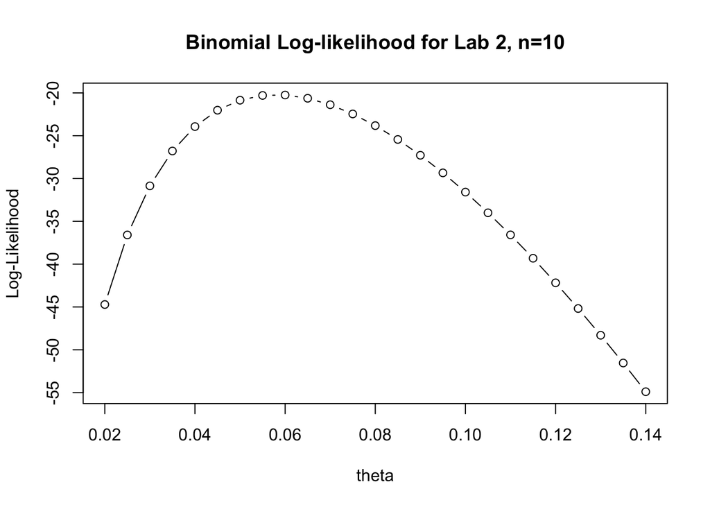

```r
plot(bloglike2~theta, ylab='Log-Likelihood', xlab='theta', type='b')
title(paste('Binomial Log-likelihood for Lab 2, n=', n, sep=''))
```

```r
set.seed(54321)
n <- 100
bdat2 <- rbinom(n, size=100, prob=.07 )   # this generates n binomial observations
bdat2
```

```
##   [1]  6  7  5  5  5 10  3  5  6  6  4  8  3  8 14  8 11  7  7  7  5  3 10  5 11
##  [26]  7  8  9  2 12  8  4 12  4 10  6 11  9 10  7 10  5  8  6 11  7  8 10  4 11
##  [51]  7  9  7  4  7  7  5  6  4  6  6 10  6  7  2  7  4  6  5  8  7  8  7 10  8
##  [76]  3  9  4  4  4  5 11  9  7  5 12  8  8  9  2  7  8  5 10  9  7  8  7  8  7
```

```r
theta <- seq(0.02, 0.14, by=.005)

bloglike2 <- 0
for (i in 1:n){
bloglike2 <- bloglike2 + dbinom(bdat2[i], size=100, prob=theta, log=TRUE)
      #computes the sum of the log of binomial probabilities over the observations
}

cbind(theta, bloglike2)
```

```
##       theta bloglike2
##  [1,] 0.020 -632.5735
##  [2,] 0.025 -522.3457
##  [3,] 0.030 -441.2234
##  [4,] 0.035 -380.2648
##  [5,] 0.040 -334.1335
##  [6,] 0.045 -299.3884
##  [7,] 0.050 -273.6808
##  [8,] 0.055 -255.3362
##  [9,] 0.060 -243.1190
## [10,] 0.065 -236.0916
## [11,] 0.070 -233.5258
## [12,] 0.075 -234.8450
## [13,] 0.080 -239.5850
## [14,] 0.085 -247.3665
## [15,] 0.090 -257.8762
## [16,] 0.095 -270.8519
## [17,] 0.100 -286.0724
## [18,] 0.105 -303.3495
## [19,] 0.110 -322.5216
## [20,] 0.115 -343.4493
## [21,] 0.120 -366.0113
## [22,] 0.125 -390.1019
## [23,] 0.130 -415.6280
## [24,] 0.135 -442.5077
## [25,] 0.140 -470.6684
```

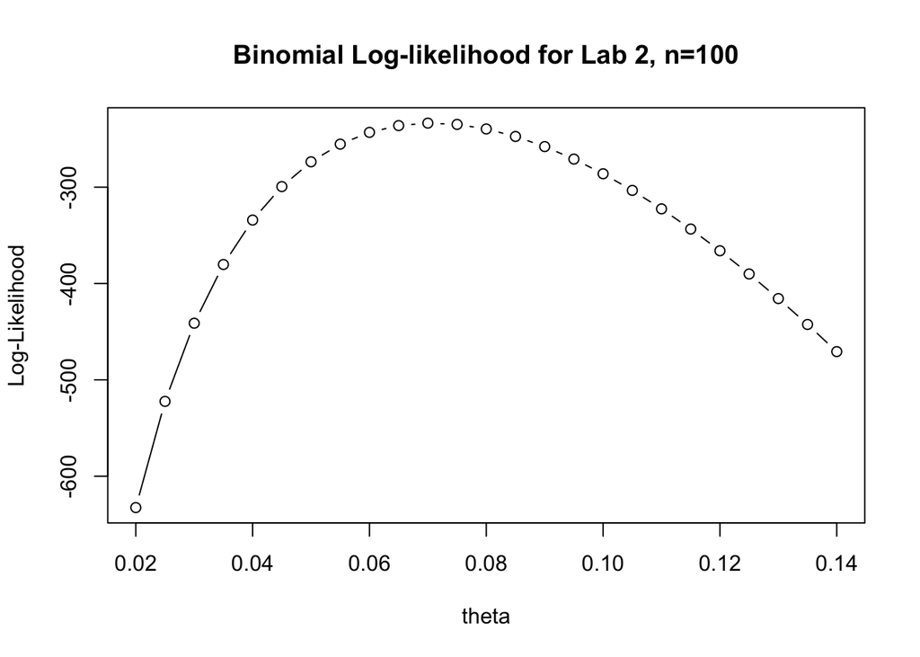

```r
plot(bloglike2~theta, ylab='Log-Likelihood', xlab='theta', type='b')
title(paste('Binomial Log-likelihood for Lab 2, n=', n, sep=''))
```